# Differential Gene Expression Analysis

Lachlan Baer

05 July, 2021

# Setup

```r
library(tidyverse)
library(magrittr)
library(parallel)
library(here)
library(AnnotationHub)
library(purrr)
library(scales)
library(kableExtra)
library(edgeR)
library(ggrepel)
library(fgsea)
library(RColorBrewer)
library(pheatmap)
library(cqn)
library(ggpubr)
```

```r
if (interactive()) setwd(here::here())
theme_set(theme_bw())
cores <- detectCores() - 1
```

```r
source(here("R/lbFuncs.R"))
```

## Annotations

```r
ah <- AnnotationHub() %>%
  subset(species == "Danio rerio") %>%
  subset(rdataclass == "EnsDb")
ensDb <- ah[["AH83189"]] ## Ens101
```

```r
transcripts <- transcripts(ensDb)
txLen <- exonsBy(ensDb, "tx") %>%
  width() %>%
  vapply(sum, integer(1))
mcols(transcripts) <- mcols(transcripts)[
  c("tx_id", "gene_id", "gc_content")
] %>%
  as.data.frame() %>%
  mutate(length = txLen)
```

```r
geneGc <- transcripts %>%
  mcols() %>%
  as_tibble() %>%
  group_by(gene_id) %>%
  summarise(
    gc_content = sum(gc_content*length) / sum(length),
    length = ceiling(median(length))
  )
```

```r
genes <- genes(ensDb)
mcols(genes) <- mcols(genes)[
  c("gene_id", "gene_name", "gene_biotype", "entrezid")
] %>%
  as.data.frame() %>%
  left_join(geneGc)
```

An `EnsDb` object was obtained for Ensembl release 101 with the `AnnotationHub` package. This contained the information required to set up gene and transcript annotations. Gene-level estimates of GC content and length estimates were also generated which are required for assessing potential biases in downstream analysis.

## Count data

```r
counts <- read_tsv(here("03_align/featureCounts/genes.out")) %>%
  set_colnames(basename(colnames(.))) %>%
  set_colnames(str_remove(colnames(.), "Aligned.sortedByCoord.out.bam"))
```

```r
metadata <- read_csv(here("files/samples.csv")) %>%
  dplyr::select(-sample) %>%
  dplyr::rename(sample = basename, genotype = Genotype) %>%
  ## We need some sample aliases that follow R naming conventions
  mutate(
    alias = c(
      paste0(rep("fAD", 7), seq(1, 7)),
      paste0(rep("fAI", 8), seq(1, 8)),
      paste0(rep("wt", 9), seq(1, 9))
    ),
    group = genotype
  )
metadata$genotype <- fct_relevel(
  metadata$genotype,
  c("WT", "EOfAD-like/+", "fAI-like/+")
)
genoCols <- metadata$genotype %>%
  levels() %>%
  length() %>%
  brewer.pal("Set1") %>%
  setNames(levels(metadata$genotype))
```

```r
minLib <- counts %>%
  dplyr::select(., str_subset(colnames(.), "KB")) %>%
  colSums() %>%
  min()
minCPM <- as.vector(cpm(10, lib.size = minLib))
minSamples <- metadata %>%
  split(.$genotype) %>%
  lapply(nrow) %>%
  unlist() %>%
  min()
dgeList <- counts %>%
  as.data.frame() %>%
  column_to_rownames("Geneid") %>%
  .[rowSums(cpm(.) >= minCPM) >= minSamples,] %>%
  DGEList(
    samples = tibble(sample = colnames(.)) %>%
      left_join(metadata),
    genes = genes[rownames(.),] %>%
      as_tibble() %>%
      dplyr::select(chromosome = seqnames, everything())
  ) %>%
  calcNormFactors()
```

Gene-level count data was loaded from `featureCounts` and imported into `R` as a `DGEList` object. Genes were removed from the counts matrix if they had less than 0.22 CPM (~10 reads) in more than 17 samples. This meant that each remaining gene must have assigned reads detected in at least one genotype group.

21147 genes remained for further analysis with library sizes ranging from 46,298,106 to 71,535,868.

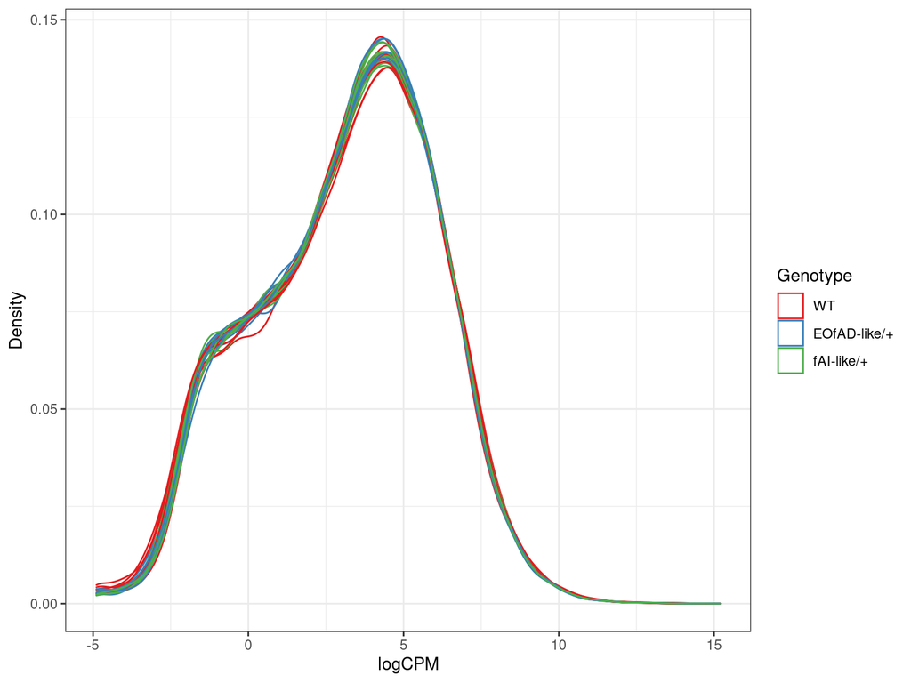

*Expression density plots for all samples after filtering*

```r
cpm(dgeList, log = TRUE) %>%
  as.data.frame() %>%
  pivot_longer(
    cols = everything(),
    names_to = "sample",
    values_to = "logCPM"
  ) %>%
  left_join(metadata) %>%
  ggplot(aes(logCPM, colour = genotype, group = sample)) +
  geom_density() +
  scale_colour_manual(values = genoCols) +
  labs(
    x = "logCPM",
    y = "Density",
    colour = "Genotype"
  )
```

# Initial DE analysis

## PCA

```r
pca <- dgeList %>%
  cpm(log = TRUE) %>%
  t() %>%
  prcomp()
pcaVars <- percent_format(0.1)(summary(pca)$importance["Proportion of Variance",])
```

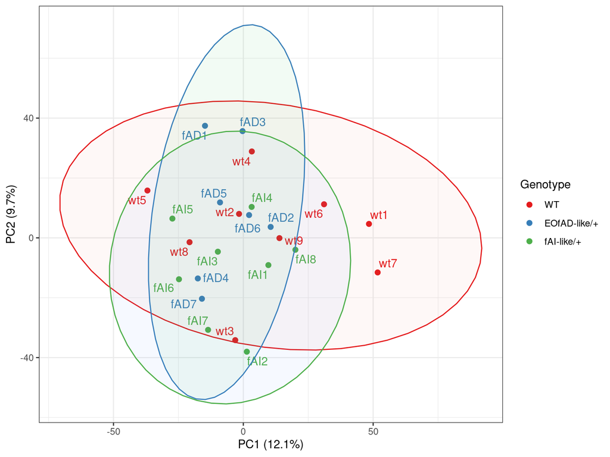

*Principal Component Analysis of gene-level counts*

```r
pca$x %>%
  as.data.frame() %>%
  rownames_to_column("sample") %>%
  left_join(metadata) %>%
  as_tibble() %>%
  ggplot(aes(PC1, PC2, colour = genotype, fill = genotype, label = alias)) +
  geom_point(size = 2) +
  geom_text_repel(show.legend = FALSE) +
  stat_ellipse(geom = "polygon", alpha = 0.05, show.legend = FALSE) +
  guides(fill = FALSE) +
  scale_colour_manual(values = genoCols) +
  labs(
    x = paste0("PC1 (", pcaVars[["PC1"]], ")"),
    y = paste0("PC2 (", pcaVars[["PC2"]], ")"),
    colour = "Genotype"
  )
```

A Principal Component Analysis (PCA) was performed using the sample logCPM values. It appears there is no clustering of genotypes, which may be due to the subtlty of the mutations and early time point (6 months). Additionally, PC1 only accounts for 12.1% of the variance.

## Design

The design matrix was defined containing an intercept representing baseline expression in wildtype samples. The remaining two columns represent the presence of either the EofAD or fAI mutant alleles.

```r
design <- model.matrix(~genotype, data = dgeList$samples) %>%
  set_colnames(str_remove(colnames(.), "genotype"))
```

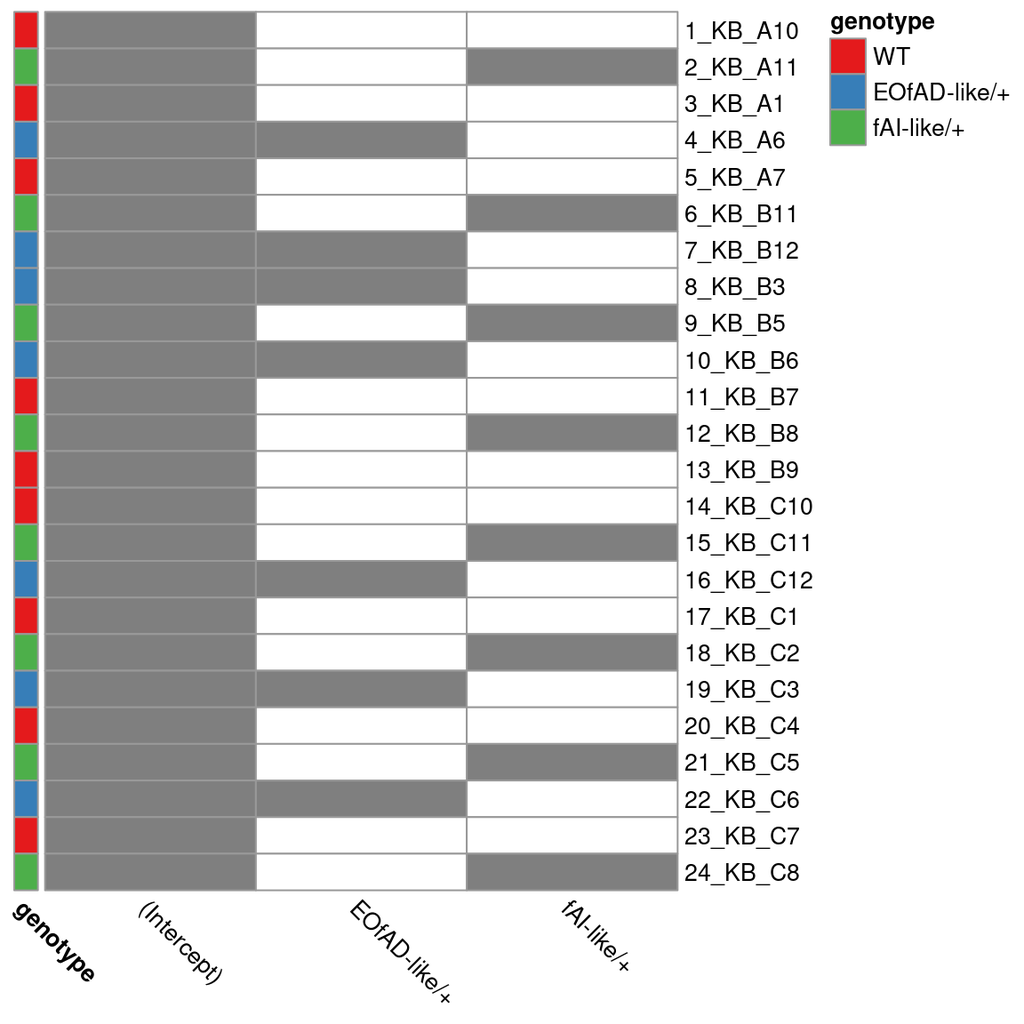

*Visualisation of the design matrix*

```r
pheatmap(
  design,
  cluster_cols = FALSE,
  cluster_rows = FALSE,
  color = c("white", "grey50"),
  annotation_row = dgeList$samples["genotype"],
  annotation_colors = list(genotype = genoCols),
  angle_col = "315",
  legend = FALSE
)
```

## Model fitting

Genewise negative binomial generalized linear models were using the `glmFit()` function of the `edgeR` package. Likelihood ratio tests were then performed for the coefficients in the model with `glmLRT()`. Here the null hypothesis, $H_0$, is testing that the true values of the coefficients are equal to 0. Due to the subtle effects of the mutation outlined in the PCA, genes were considered to be DE if they had an FDR-adjusted p-value < 0.05, as opposed to more stringent error rate control methods such as Bonferroni.

```r
alpha <- 0.05
minLfc <- 1
fit <- estimateDisp(dgeList, design) %>%
  glmFit()
topTables <- colnames(design)[2:3] %>%
  sapply(function(x){
    glmLRT(fit, coef = x) %>%
      topTags(n = Inf) %>%
      .[["table"]] %>%
      as_tibble() %>%
      arrange(PValue) %>%
      dplyr::select(
        gene_id, gene_name, logFC, logCPM, PValue, FDR, everything()
      ) %>%
      mutate(
        coef = x,
        bonfP = p.adjust(PValue, "bonf"),
        DE = ifelse(FDR < 0.05, TRUE, FALSE)
      )
  }, simplify = FALSE)
```

With this criteria, the following genes were classified as DE:

```r
topTables$`EOfAD-like/+` %>%
  dplyr::filter(DE) %>%
  dplyr::select(gene_id, gene_name, logFC, logCPM, PValue, FDR, bonfP) %>%
  mutate(
    logCPM = formatC(logCPM, digits = 2, format = "f"),
    logFC = formatC(logFC, digits = 2, format = "f"),
    PValue = formatC(PValue, digits = 2, format = "e"),
    FDR = formatC(FDR, digits = 2, format = "e"),
    bonfP = formatC(bonfP, digits = 2, format = "e"),
  ) %>%
  kable(
    align = "l",
    caption = paste(
      "The", nrow(.), "differentially expressed genes for EOfAD genotype",
      "in comparison to wildtype"
    )
  ) %>%
  kable_styling(
    bootstrap_options = c("striped", "hover", "condensed", "responsive")
  )
```

The 10 differentially expressed genes for EOfAD genotype in comparison to wildtype

| gene_id | gene_name | logFC | logCPM | PValue | FDR | bonfP |
| --- | --- | --- | --- | --- | --- | --- |
| ENSDARG00000078322 | col12a1a | 1.87 | 3.83 | 6.26e-21 | 1.32e-16 | 1.32e-16 |
| ENSDARG00000093378 | si:ch211-235i11.5 | 0.63 | 2.96 | 3.36e-11 | 3.55e-07 | 7.10e-07 |
| ENSDARG00000079324 | ano9b | 1.38 | -1.19 | 3.16e-08 | 2.22e-04 | 6.67e-04 |
| ENSDARG00000020448 | adi1 | 0.54 | 2.81 | 3.15e-07 | 1.67e-03 | 6.67e-03 |
| ENSDARG00000092191 | CR318588.1 | 3.32 | 2.45 | 1.25e-06 | 4.99e-03 | 2.65e-02 |
| ENSDARG00000001993 | myhb | 4.04 | 2.38 | 1.41e-06 | 4.99e-03 | 2.99e-02 |
| ENSDARG00000088298 | si:ch211-235i11.4 | 0.34 | 3.57 | 2.44e-06 | 7.36e-03 | 5.15e-02 |
| ENSDARG00000094719 | CR318588.3 | 2.05 | 2.71 | 4.64e-06 | 1.23e-02 | 9.81e-02 |
| ENSDARG00000056065 | mov10b.2 | 1.38 | -1.77 | 1.68e-05 | 3.95e-02 | 3.56e-01 |
| ENSDARG00000088507 | znf982 | 0.39 | 2.28 | 2.31e-05 | 4.89e-02 | 4.89e-01 |

```r
topTables$`fAI-like/+` %>%
  dplyr::filter(DE) %>%
  dplyr::select(gene_id, gene_name, logFC, logCPM, PValue, FDR, bonfP) %>%
  mutate(
    logCPM = formatC(logCPM, digits = 2, format = "f"),
    logFC = formatC(logFC, digits = 2, format = "f"),
    PValue = formatC(PValue, digits = 2, format = "e"),
    FDR = formatC(FDR, digits = 2, format = "e"),
    bonfP = formatC(bonfP, digits = 2, format = "e"),
  ) %>%
  kable(
    align = "l",
    caption = paste(
      "The", nrow(.), "differentially expressed genes for fAI genotype",
      "in comparison to wildtype"
    )
  ) %>%
  kable_styling(
    bootstrap_options = c("striped", "hover", "condensed", "responsive")
  )
```

The 6 differentially expressed genes for fAI genotype in comparison to wildtype

| gene_id | gene_name | logFC | logCPM | PValue | FDR | bonfP |
| --- | --- | --- | --- | --- | --- | --- |
| ENSDARG00000004870 | psen1 | -0.78 | 5.33 | 3.84e-75 | 8.13e-71 | 8.13e-71 |
| ENSDARG00000005179 | dglucy | -0.96 | 5.01 | 3.70e-09 | 3.91e-05 | 7.82e-05 |
| ENSDARG00000061758 | sh3pxd2ab | -3.04 | 1.06 | 3.02e-08 | 2.13e-04 | 6.39e-04 |
| ENSDARG00000067665 | fam167aa | -3.39 | 0.33 | 7.62e-08 | 4.03e-04 | 1.61e-03 |
| ENSDARG00000105453 | kcnk17 | -1.52 | -1.00 | 7.63e-07 | 3.23e-03 | 1.61e-02 |
| ENSDARG00000094098 | si:ch211-278p9.3 | -2.29 | -2.35 | 1.22e-05 | 4.28e-02 | 2.57e-01 |

```r
deCols <- c(`TRUE` = "red", `FALSE` = "grey50")
```

## Bias checks

### MA plots

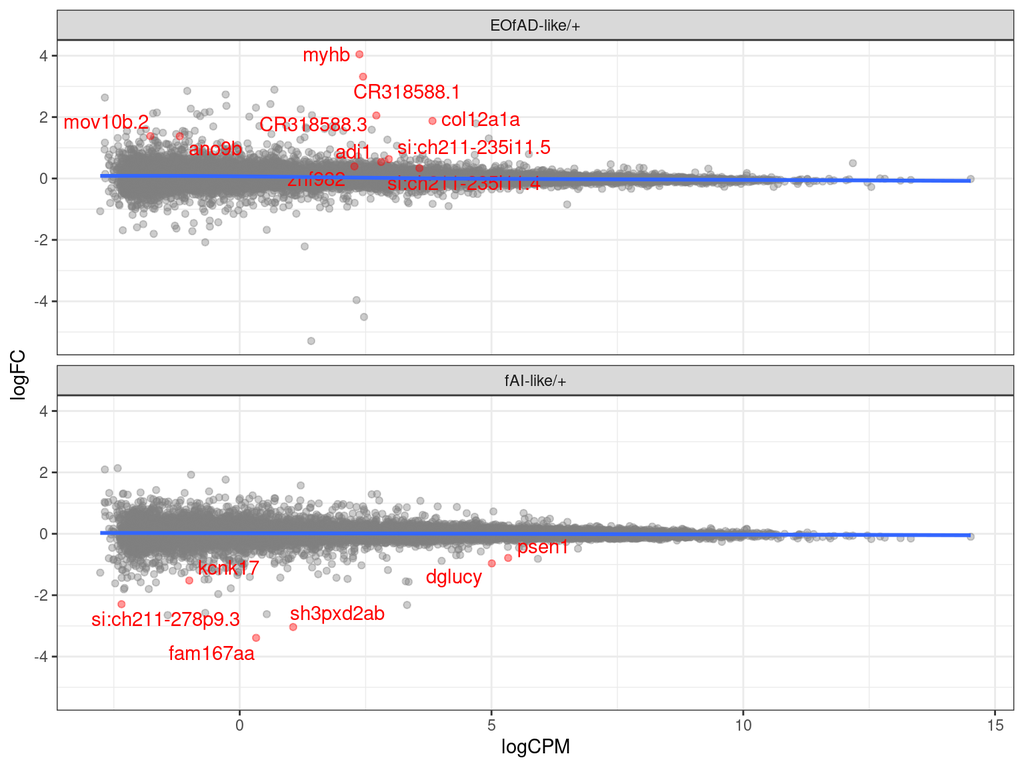

*MA plots checking for logFC artefacts across the range of expression values. The average logFC appears consistant across all expression values for both comparisons*

```r
topTables %>%
  bind_rows() %>%
  arrange(DE) %>%
  ggplot(aes(logCPM, logFC)) +
  geom_point(aes(colour = DE), alpha = 0.4) +
  geom_text_repel(
    aes(label = gene_name, colour = DE),
    data = . %>% dplyr::filter(DE)
  ) +
  geom_smooth(se = FALSE) +
  facet_wrap(~coef, nrow = 2) +
  scale_y_continuous(breaks = seq(-8, 8, by = 2)) +
  scale_colour_manual(values = deCols) +
  theme(legend.position = "none")
```

### GC content

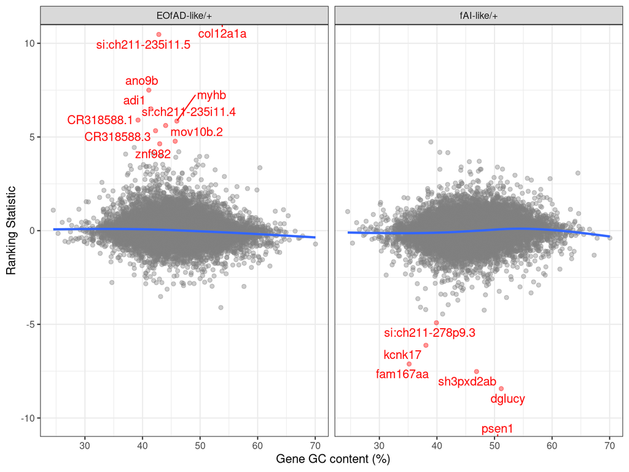

*GC content bias for differential expression. GC content is shown against the ranking statistic, calculated by -log10(p) multiple by the sign of logFC. Some bias was observed for both comparisons, in particular for the fAI genotype, and may be of concern for this dataset.*

```r
topTables %>%
  bind_rows() %>%
  mutate(stat = -sign(logFC)*log10(PValue)) %>%
  ggplot(aes(gc_content, stat)) +
  geom_point(aes(colour = DE), alpha = 0.4) +
  geom_smooth(se = FALSE) +
  facet_wrap(~coef)  +
  geom_text_repel(
    aes(label = gene_name, colour = DE),
    data = . %>% dplyr::filter(DE)
  ) +
  labs(
    x = " Gene GC content (%)",
    y = "Ranking Statistic"
  ) +
  coord_cartesian(ylim = c(-10, 10)) +
  scale_colour_manual(values = deCols) +
  theme(legend.position = "none")
```

### Gene length

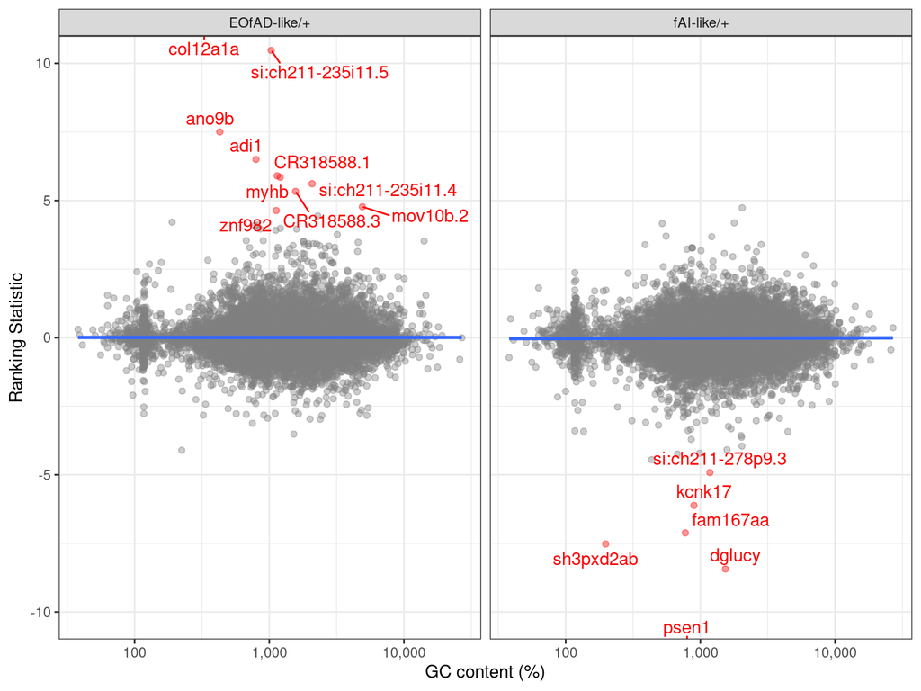

*Gene length bias for differential expression. Gene length is shown against the ranking statistic, calculated by -log10(p) multiple by the sign of logFC. No bias is observed for either comparison.*

```r
topTables %>%
  bind_rows() %>%
  mutate(stat = -sign(logFC)*log10(PValue)) %>%
  ggplot(aes(length, stat)) +
  geom_point(aes(colour = DE), alpha = 0.4) +
  geom_smooth(se = FALSE) +
  facet_wrap(~coef)  +
  geom_text_repel(
    aes(label = gene_name, colour = DE),
    data = . %>% dplyr::filter(DE)
  ) +
  labs(
    x = "GC content (%)",
    y = "Ranking Statistic"
  ) +
  coord_cartesian(ylim = c(-10, 10)) +
  scale_x_log10(labels = comma) +
  scale_colour_manual(values = deCols) +
  theme(legend.position = "none")
```

# Conditional Quantile Normalisation

Conditional Quantile Normalisation (CQN) is a procedure that can account for GC content and length biases in differential expression and is implemented with package `cqn`. It does this by making by calculating offset values that can be incorporated into the GLM. As GC content was noted as being of concern, but length showed no bias, only GC content was used to calculate the offsets. The `glm.offset` values from the output of `cqn` were added to the original `DGEList` object.

```r
cqn <- cqn(
  counts = dgeList$counts,
  x = dgeList$genes$gc_content,
  lengths = rep(1000, times = nrow(dgeList)),
  sizeFactors = dgeList$samples$lib.size,
  lengthMethod = "fixed"
)
```

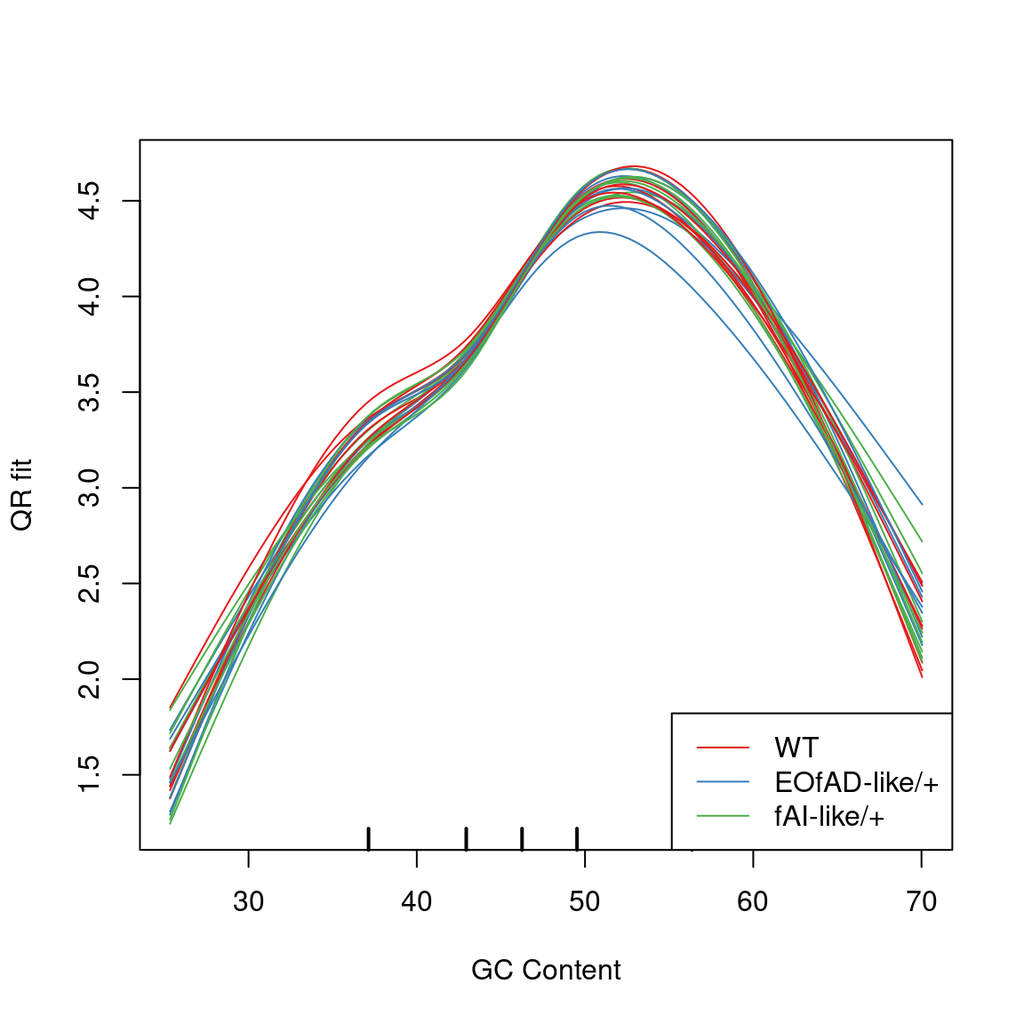

```r
cqnplot(cqn, n = 1, xlab = "GC Content", col = genoCols)
legend(
  "bottomright",
  legend = levels(metadata$genotype),
  col = genoCols,
  lty = 1
)
```

```r
dgeList$offset <- cqn$glm.offset
```

## PCA

```r
cpm_cqn <- cqn %>%
  with(y + offset)
```

```r
pca_cqn <- cpm_cqn %>%
  t() %>%
  prcomp()
pcaVars <- percent_format(0.1)(summary(pca_cqn)$importance["Proportion of Variance",])
```

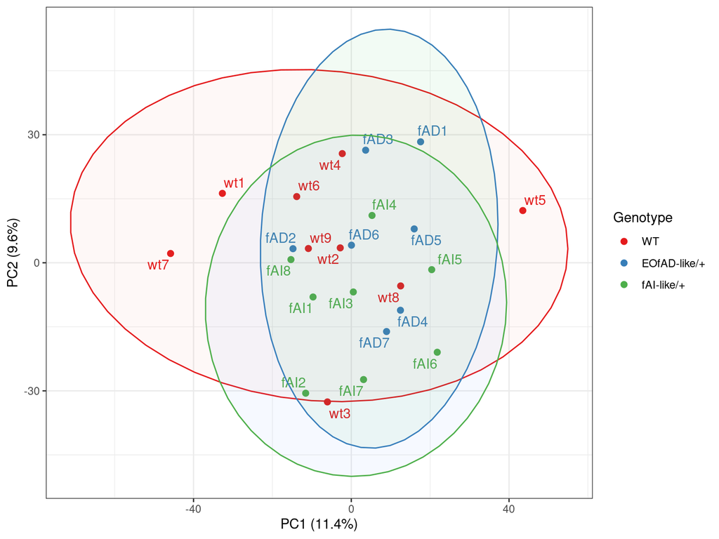

*Principal Component Analysis of gene-level counts post CQN.*

```r
pca_cqn$x %>%
  as.data.frame() %>%
  rownames_to_column("sample") %>%
  left_join(metadata) %>%
  as_tibble() %>%
  ggplot(aes(PC1, PC2, colour = genotype, fill = genotype, label = alias)) +
  geom_point(size = 2) +
  geom_text_repel(show.legend = FALSE) +
  stat_ellipse(geom = "polygon", alpha = 0.05, show.legend = FALSE) +
  guides(fill = FALSE) +
  scale_colour_manual(values = genoCols) +
  labs(
    x = paste0("PC1 (", pcaVars[["PC1"]], ")"),
    y = paste0("PC2 (", pcaVars[["PC2"]], ")"),
    colour = "Genotype"
  )
```

There was very little improvement in separation of genotype groups after CQN, and PC1 still only accounted for 11.4% of the variation. The x-axis of the PCA plot appears to be flipped, but this normal as the signs of PC values are somewhat arbitrary.

## Model fitting

After incorporation of the offset values into the `DGEList` object, dispersion estimates were calculated and models were fitted as done pre CQN.

```r
fit_cqn <- estimateDisp(dgeList, design) %>%
  glmFit()
topTables_cqn <- colnames(design)[2:3] %>%
  sapply(function(x){
    glmLRT(fit_cqn, coef = x) %>%
      topTags(n = Inf) %>%
      .[["table"]] %>%
      as_tibble() %>%
      arrange(PValue) %>%
      dplyr::select(
        gene_id, gene_name, logFC, logCPM, PValue, FDR, everything()
      ) %>%
      mutate(
        coef = x,
        bonfP = p.adjust(PValue, "bonf"),
        DE = ifelse(FDR < 0.05, TRUE, FALSE)
      )
  }, simplify = FALSE)
```

```r
topTables_cqn$`EOfAD-like/+` %>%
  dplyr::filter(DE) %>%
  dplyr::select(gene_id, gene_name, logFC, logCPM, PValue, FDR, bonfP) %>%
  mutate(
    logCPM = formatC(logCPM, digits = 2, format = "f"),
    logFC = formatC(logFC, digits = 2, format = "f"),
    PValue = formatC(PValue, digits = 2, format = "e"),
    FDR = formatC(FDR, digits = 2, format = "e"),
    bonfP = formatC(bonfP, digits = 2, format = "e"),
  ) %>%
  kable(
    align = "l",
    caption = paste(
      "The", nrow(.), "differentially expressed genes for EOfAD genotype",
      "in comparison to wildtype after CQN"
    )
  ) %>%
  kable_styling(
    bootstrap_options = c("striped", "hover", "condensed", "responsive")
  )
```

The 8 differentially expressed genes for EOfAD genotype in comparison to wildtype after CQN

| gene_id | gene_name | logFC | logCPM | PValue | FDR | bonfP |
| --- | --- | --- | --- | --- | --- | --- |
| ENSDARG00000078322 | col12a1a | 1.87 | 3.83 | 9.25e-21 | 1.96e-16 | 1.96e-16 |
| ENSDARG00000093378 | si:ch211-235i11.5 | 0.62 | 2.96 | 4.47e-11 | 4.73e-07 | 9.45e-07 |
| ENSDARG00000020448 | adi1 | 0.52 | 2.81 | 2.85e-09 | 2.01e-05 | 6.02e-05 |
| ENSDARG00000079324 | ano9b | 1.35 | -1.19 | 6.51e-09 | 3.44e-05 | 1.38e-04 |
| ENSDARG00000001993 | myhb | 4.22 | 2.38 | 1.47e-06 | 6.23e-03 | 3.12e-02 |
| ENSDARG00000092191 | CR318588.1 | 3.21 | 2.45 | 2.25e-06 | 7.94e-03 | 4.77e-02 |
| ENSDARG00000094719 | CR318588.3 | 2.01 | 2.71 | 3.32e-06 | 1.00e-02 | 7.02e-02 |
| ENSDARG00000088298 | si:ch211-235i11.4 | 0.33 | 3.57 | 6.44e-06 | 1.70e-02 | 1.36e-01 |

```r
topTables_cqn$`fAI-like/+` %>%
  dplyr::filter(DE) %>%
  dplyr::select(gene_id, gene_name, logFC, logCPM, PValue, FDR, bonfP) %>%
  mutate(
    logCPM = formatC(logCPM, digits = 2, format = "f"),
    logFC = formatC(logFC, digits = 2, format = "f"),
    PValue = formatC(PValue, digits = 2, format = "e"),
    FDR = formatC(FDR, digits = 2, format = "e"),
    bonfP = formatC(bonfP, digits = 2, format = "e"),
  ) %>%
  kable(
    align = "l",
    caption = paste(
      "The", nrow(.), "differentially expressed genes for fAI genotype",
      "in comparison to wildtype after CQN"
    )
  ) %>%
  kable_styling(
    bootstrap_options = c("striped", "hover", "condensed", "responsive")
  )
```

The 13 differentially expressed genes for fAI genotype in comparison to wildtype after CQN

| gene_id | gene_name | logFC | logCPM | PValue | FDR | bonfP |
| --- | --- | --- | --- | --- | --- | --- |
| ENSDARG00000004870 | psen1 | -0.82 | 5.33 | 8.57e-52 | 1.81e-47 | 1.81e-47 |
| ENSDARG00000061758 | sh3pxd2ab | -3.31 | 1.06 | 2.19e-09 | 2.31e-05 | 4.63e-05 |
| ENSDARG00000005179 | dglucy | -1.01 | 5.01 | 6.87e-09 | 4.84e-05 | 1.45e-04 |
| ENSDARG00000067665 | fam167aa | -3.62 | 0.33 | 1.23e-08 | 6.50e-05 | 2.60e-04 |
| ENSDARG00000105453 | kcnk17 | -1.66 | -1.00 | 9.72e-08 | 4.11e-04 | 2.06e-03 |
| ENSDARG00000101775 | zgc:172014 | -2.07 | -0.43 | 1.48e-06 | 5.23e-03 | 3.14e-02 |
| ENSDARG00000079992 | senp6b | 1.79 | -0.96 | 3.23e-06 | 9.76e-03 | 6.83e-02 |
| ENSDARG00000104031 | mrpl33 | -0.26 | 4.08 | 5.37e-06 | 1.42e-02 | 1.14e-01 |
| ENSDARG00000053240 | kif6 | -0.89 | 0.78 | 1.11e-05 | 2.61e-02 | 2.35e-01 |
| ENSDARG00000092522 | nnt2 | -0.77 | 0.29 | 1.36e-05 | 2.87e-02 | 2.87e-01 |
| ENSDARG00000081758 | NC_002333.12 | -1.10 | 0.95 | 2.10e-05 | 3.78e-02 | 4.45e-01 |
| ENSDARG00000037613 | lgals8b | 0.36 | 4.43 | 2.14e-05 | 3.78e-02 | 4.54e-01 |
| ENSDARG00000100743 | si:dkey-190j3.4 | 1.09 | -0.52 | 2.84e-05 | 4.62e-02 | 6.00e-01 |

## Bias checks

### MA plots

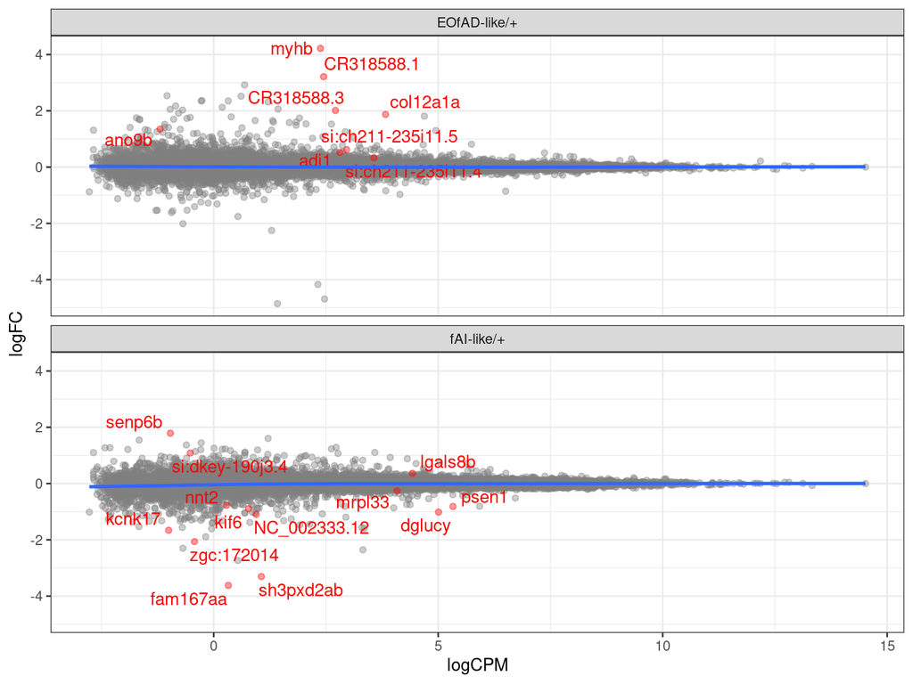

*MA plots checking for logFC artefacts across the range of expression values. The average logFC remains consistant across all expression values for both comparisons after CQN*

```r
topTables_cqn %>%
  bind_rows() %>%
  arrange(DE) %>%
  ggplot(aes(logCPM, logFC)) +
  geom_point(aes(colour = DE), alpha = 0.4) +
  geom_text_repel(
    aes(label = gene_name, colour = DE),
    data = . %>% dplyr::filter(DE)
  ) +
  geom_smooth(se = FALSE) +
  facet_wrap(~coef, nrow = 2) +
  scale_y_continuous(breaks = seq(-8, 8, by = 2)) +
  scale_colour_manual(values = deCols) +
  theme(legend.position = "none")
```

### GC content

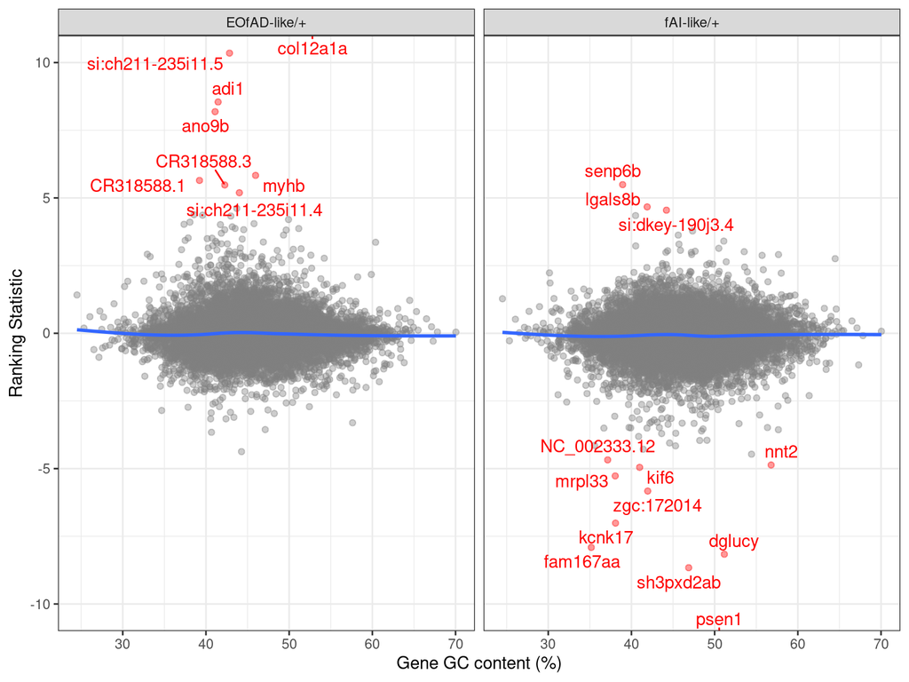

*GC content bias for differential expression. GC content is shown against the ranking statistic, calculated by -log10(p) multiple by the sign of logFC. There was still a small amount of residual bias post CQN, but an improvement was noted, particulary for the fAI genotype.*

```r
topTables_cqn %>%
  bind_rows() %>%
  mutate(stat = -sign(logFC)*log10(PValue)) %>%
  ggplot(aes(gc_content, stat)) +
  geom_point(aes(colour = DE), alpha = 0.4) +
  geom_smooth(se = FALSE) +
  facet_wrap(~coef)  +
  geom_text_repel(
    aes(label = gene_name, colour = DE),
    data = . %>% dplyr::filter(DE)
  ) +
  labs(
    x = "Gene GC content (%)",
    y = "Ranking Statistic"
  ) +
  coord_cartesian(ylim = c(-10, 10)) +
  scale_colour_manual(values = deCols) +
  theme(legend.position = "none")
```

# Results

## DE genes

```r
geneLabeller <- as_labeller(
  structure(dgeList$genes$gene_name, names = dgeList$genes$gene_id)
)
```

```r
fadComp <- metadata %>%
  dplyr::filter(str_detect(alias, "(fAD|wt)")) %>%
  pull(sample)
faiComp <- metadata %>%
  dplyr::filter(str_detect(alias, "(fAI|wt)")) %>%
  pull(sample)
```

```r
deGenes <- lapply(topTables_cqn, function(x){
  dplyr::filter(x, DE) %>%
    pull(gene_id)
})
deCpmPlots <- lapply(seq_along(deGenes), function(x){
  cpms <- cpm_cqn[deGenes[[x]],] %>%
    as.data.frame() %>%
    rownames_to_column("gene_id") %>%
    gather(key = "sample", value = logCPM, -gene_id) %>%
    as_tibble() %>%
    left_join(metadata[,c("sample", "genotype")])
  if (names(deGenes[x]) == "EOfAD-like/+") {
    dplyr::filter(cpms, sample %in% fadComp) %>%
      ggplot(aes(genotype, logCPM)) +
      geom_boxplot(aes(fill = genotype)) +
      labs(title = paste(names(deGenes[x]), "DE genes")) +
      facet_wrap(
        ~gene_id,
        labeller = geneLabeller,
        nrow = 2
      ) +
      theme(
        legend.position = "none",
        title = element_text(face = "bold")
      )
  } else if (names(deGenes[x]) == "fAI-like/+") {
    dplyr::filter(cpms, sample %in% faiComp) %>%
      ggplot(aes(genotype, logCPM)) +
      geom_boxplot(aes(fill = genotype)) +
      labs(title = paste(names(deGenes[x]), "DE genes")) +
      facet_wrap(
        ~gene_id,
        labeller = geneLabeller,
        nrow = 4
      ) +
      theme(
        legend.position = "none",
        title = element_text(face = "bold")
      )
  }
})
```

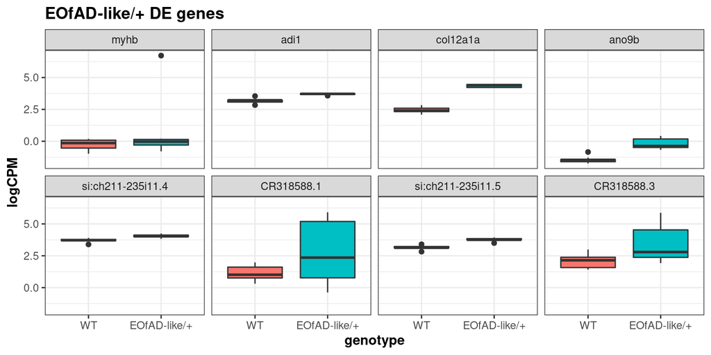

```r
deCpmPlots[[1]]
```

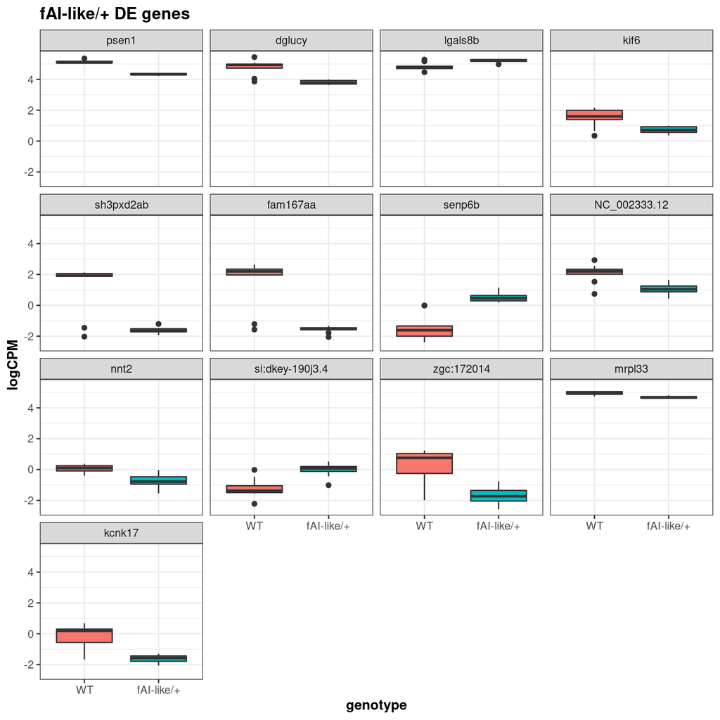

```r
deCpmPlots[[2]]
```

## Export data

Final results were exported as Rds files for further analysis.

```r
saveRDS(topTables, here("files/topTables.Rds"))
saveRDS(topTables_cqn, here("files/topTables_cqn.Rds"))
```